# ggplot2

Chris

10/30/2019

## ggplot2

- [Documentation](https://www.rdocumentation.org/packages/ggplot2/versions/3.2.1)
- [Cheat sheet](https://rstudio.com/wp-content/uploads/2015/03/ggplot2-cheatsheet.pdf)

## Formatting Data

Lets read in some expression data. This is genome-wide expression data (in transcript counts) of 6 samples in normal media (YPD) and 6 samples in normal media plus treatment with rapamycin (RAPA) for 30 minutes.

```r
plt.data <- read.delim("ggplot_gene_expression.tsv")
print("Structure:")
```

```
## [1] "Structure:"
```

```r
str(plt.data)
```

```
## 'data.frame':    6830 obs. of  12 variables:
##  $ YPD1 : int  0 0 0 0 0 0 8 0 3 0 ...
##  $ YPD2 : int  0 0 0 0 0 0 5 0 7 0 ...
##  $ YPD3 : int  0 0 0 0 0 0 2 0 1 0 ...
##  $ YPD4 : int  0 0 0 0 0 0 6 0 1 0 ...
##  $ YPD5 : int  0 0 0 0 0 1 5 0 1 0 ...
##  $ YPD6 : int  0 0 0 0 0 0 4 0 0 0 ...
##  $ RAPA1: int  0 0 0 0 1 5 22 0 0 0 ...
##  $ RAPA2: int  1 0 0 0 0 6 16 0 1 0 ...
##  $ RAPA3: int  0 0 0 0 0 3 12 0 1 0 ...
##  $ RAPA4: int  0 0 0 0 1 2 20 0 4 0 ...
##  $ RAPA5: int  0 0 0 0 0 1 16 0 1 0 ...
##  $ RAPA6: int  1 0 0 0 0 4 18 0 2 0 ...
```

```r
print("Summary:")
```

```
## [1] "Summary:"
```

```r
summary(plt.data)
```

```
##       YPD1               YPD2               YPD3             YPD4
##  Min.   :    0.00   Min.   :    0.00   Min.   :   0.0   Min.   :    0.00
##  1st Qu.:    0.00   1st Qu.:    0.00   1st Qu.:   0.0   1st Qu.:    0.00
##  Median :    6.00   Median :    6.00   Median :   2.0   Median :    7.00
##  Mean   :   66.62   Mean   :   72.64   Mean   :  25.3   Mean   :   72.66
##  3rd Qu.:   21.00   3rd Qu.:   22.00   3rd Qu.:   8.0   3rd Qu.:   22.00
##  Max.   :10161.00   Max.   :11354.00   Max.   :3843.0   Max.   :11262.00
##       YPD5               YPD6             RAPA1
##  Min.   :    0.00   Min.   :   0.00   Min.   :    0.00
##  1st Qu.:    0.00   1st Qu.:   0.00   1st Qu.:    1.00
##  Median :    6.00   Median :   4.00   Median :    8.00
##  Mean   :   69.63   Mean   :  50.61   Mean   :   51.18
##  3rd Qu.:   22.00   3rd Qu.:  16.00   3rd Qu.:   26.00
##  Max.   :10738.00   Max.   :7861.00   Max.   :11024.00
##      RAPA2              RAPA3             RAPA4              RAPA5
##  Min.   :    0.00   Min.   :   0.00   Min.   :    0.00   Min.   :    0.0
##  1st Qu.:    1.00   1st Qu.:   0.00   1st Qu.:    1.00   1st Qu.:    1.0
##  Median :   10.00   Median :   5.00   Median :    8.00   Median :    9.0
##  Mean   :   63.53   Mean   :  29.27   Mean   :   50.08   Mean   :   56.4
##  3rd Qu.:   33.00   3rd Qu.:  15.00   3rd Qu.:   26.00   3rd Qu.:   29.0
##  Max.   :13722.00   Max.   :6249.00   Max.   :10883.00   Max.   :12257.0
##      RAPA6
##  Min.   :   0.00
##  1st Qu.:   1.00
##  Median :   7.00
##  Mean   :  45.69
##  3rd Qu.:  23.75
##  Max.   :9844.00
```

```r
print("Rownames:")
```

```
## [1] "Rownames:"
```

```r
head(rownames(plt.data))
```

```
## [1] "YDL248W"   "YDL247W.A" "YDL247W"   "YDL246C"   "YDL245C"   "YDL244W"
```

First thing’s first; is this data normalized already?

```r
print("Counts per experiment:")
```

```
## [1] "Counts per experiment:"
```

```r
print(colSums(plt.data))
```

```
##   YPD1   YPD2   YPD3   YPD4   YPD5   YPD6  RAPA1  RAPA2  RAPA3  RAPA4
## 454987 496114 172790 496240 475562 345648 349538 433911 199934 342072
##  RAPA5  RAPA6
## 385236 312057
```

```r
# This 'sweeps' the column totals out (converting each gene measurement to a proportion of total counts for that experiment)
# Then it multiplies by 1 million. The resulting data frame is normalized for count depth (and has the units TPM)
plt.data.normalized <- sweep(plt.data, 2, colSums(plt.data), FUN = "/") * 1e6
colSums(plt.data.normalized)
```

```
##  YPD1  YPD2  YPD3  YPD4  YPD5  YPD6 RAPA1 RAPA2 RAPA3 RAPA4 RAPA5 RAPA6
## 1e+06 1e+06 1e+06 1e+06 1e+06 1e+06 1e+06 1e+06 1e+06 1e+06 1e+06 1e+06
```

Excellent; now each experiment has the same depth. However, ggplot works better with long format data.

```r
ypd.replicates <- c("YPD1", "YPD2", "YPD3", "YPD4", "YPD5", "YPD6")
rapa.replicates <- c("RAPA1", "RAPA2", "RAPA3", "RAPA4", "RAPA5", "RAPA6")

melt.expression.data <- function(expr.df) {
  # We need to make the rownames into a column:
  expr.df$Gene <- rownames(expr.df)

  melted <- reshape2::melt(expr.df, id.vars="Gene", variable.name="Replicate", value.name="Expression")

  # Lets go ahead and add an "Experiment" column which has the experimental group YPD or RAPA
  melted$Experiment <- NA
  melted[melted$Replicate %in% ypd.replicates, "Experiment"] <- "YPD"
  melted[melted$Replicate %in% rapa.replicates, "Experiment"] <- "RAPA"

  # And I'm going to make sure that this is a factor (instead of a character column)
  melted$Experiment <- as.factor(melted$Experiment)

  return(melted)
}

plt.data.melt <- melt.expression.data(plt.data.normalized)

head(plt.data.melt)
```

```
##        Gene Replicate Expression Experiment
## 1   YDL248W      YPD1          0        YPD
## 2 YDL247W.A      YPD1          0        YPD
## 3   YDL247W      YPD1          0        YPD
## 4   YDL246C      YPD1          0        YPD
## 5   YDL245C      YPD1          0        YPD
## 6   YDL244W      YPD1          0        YPD
```

Much better. Now lets do some plotting.

## Plotting expression of one gene

I like the ggplot `theme_classic`, so I’m going to set that as a default theme. I could add it to every plot, but this is easier.

```r
ggplot2::theme_set(theme_classic())
```

I am interested in the expression of GAP1. In this data set, it is listed under the systematic name “YKR039W”

```r
gap1 <- "YKR039W"
gap1.data <- plt.data.melt[plt.data.melt$Gene == gap1,]
print(gap1.data)
```

```
##          Gene Replicate  Expression Experiment
## 5345  YKR039W      YPD1    2.197865        YPD
## 12175 YKR039W      YPD2    0.000000        YPD
## 19005 YKR039W      YPD3    0.000000        YPD
## 25835 YKR039W      YPD4    0.000000        YPD
## 32665 YKR039W      YPD5    6.308326        YPD
## 39495 YKR039W      YPD6    0.000000        YPD
## 46325 YKR039W     RAPA1 1344.632057       RAPA
## 53155 YKR039W     RAPA2 1297.501100       RAPA
## 59985 YKR039W     RAPA3 1300.429142       RAPA
## 66815 YKR039W     RAPA4 1327.205968       RAPA
## 73645 YKR039W     RAPA5 1230.414603       RAPA
## 80475 YKR039W     RAPA6 1349.112502       RAPA
```

Now I can plot the expression:

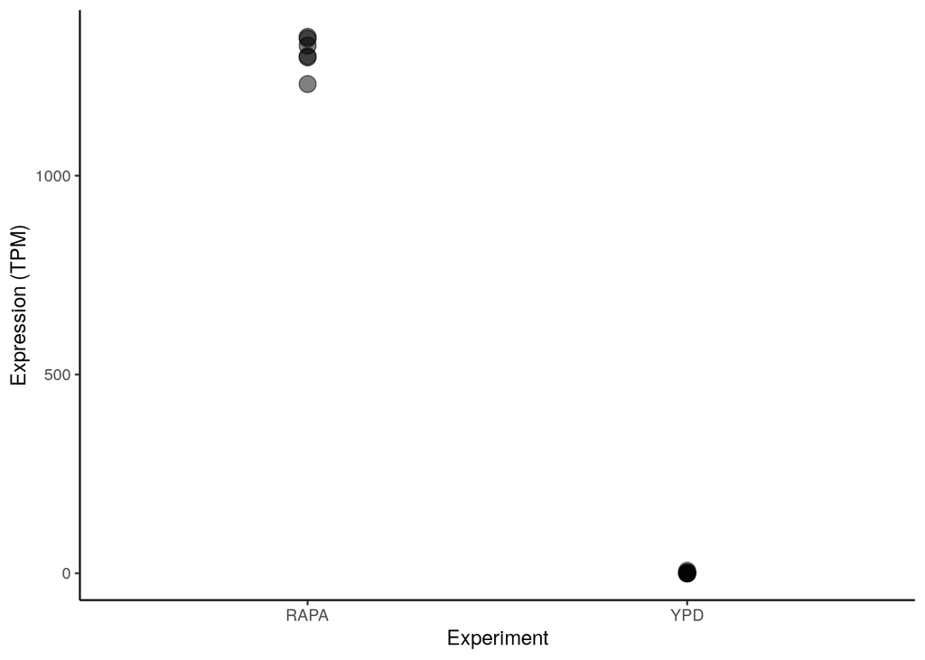

```r
gap1.plt <- ggplot(gap1.data, aes(x=Experiment, y=Expression)) +
  geom_point(size=4, alpha=0.5) +
  labs(y="Expression (TPM)")

print(gap1.plt)
```

A good start. Lets add a boxplot to this though.

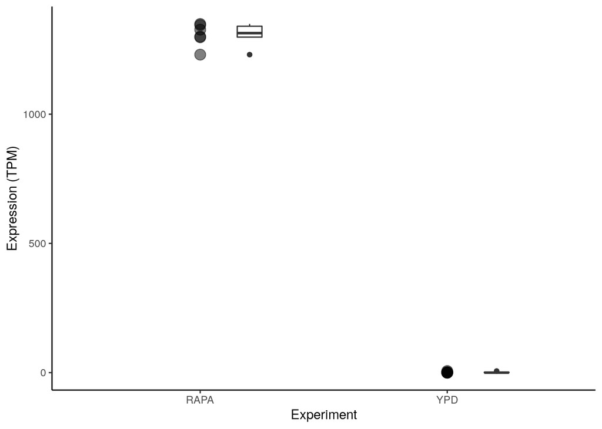

```r
gap1.plt <- gap1.plt +
  geom_boxplot(position = position_nudge(x=0.2), width=0.1)

print(gap1.plt)
```

OK, looks good - I prefer the control (YPD) to be in the left spot on my plot though.

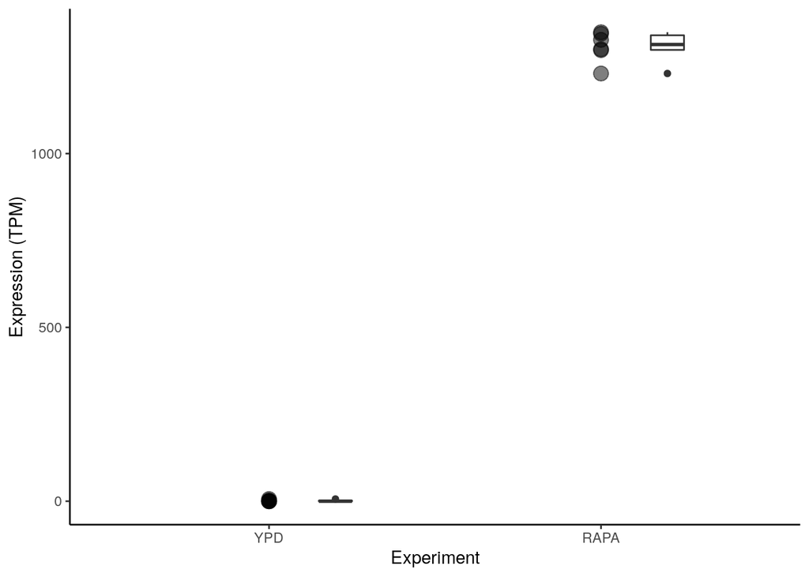

```r
#
gap1.plt <- gap1.plt +
  scale_x_discrete(limits = c("YPD", "RAPA"))

print(gap1.plt)
```

Perfect.

## Asthetics

Aesthetics are created with `aes()` and define connections between a variable in the data and an axis or a parameter of the plot

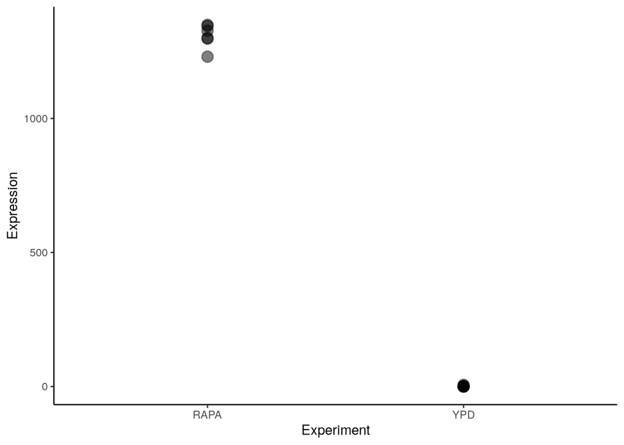

```r
# Compare an asthetic that maps "Experiment" to X
ggplot() +
  geom_point(data=gap1.data, mapping = aes(x=Experiment, y=Expression), size=4, alpha=0.5)
```

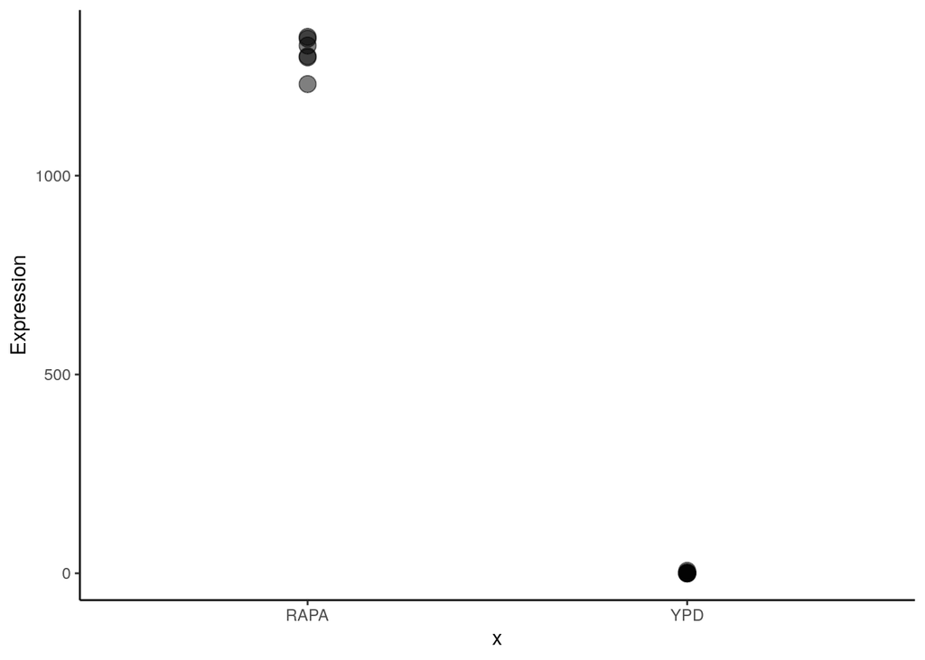

```r
# Against creating two geometry layers and selecting the Experiment levels by hand
ggplot() +
  geom_point(data=gap1.data[gap1.data$Experiment == "YPD", "Expression", drop=F], mapping = aes(x="YPD", y=Expression), size=4, alpha=0.5) +
  geom_point(data=gap1.data[gap1.data$Experiment == "RAPA", "Expression", drop=F], mapping = aes(x="RAPA", y=Expression), size=4, alpha=0.5)
```

Asthetics can be used to connect variables in the data to almost any plot parameter. Lets look at RPL12A too (in this data, it’s gene YEL054C)

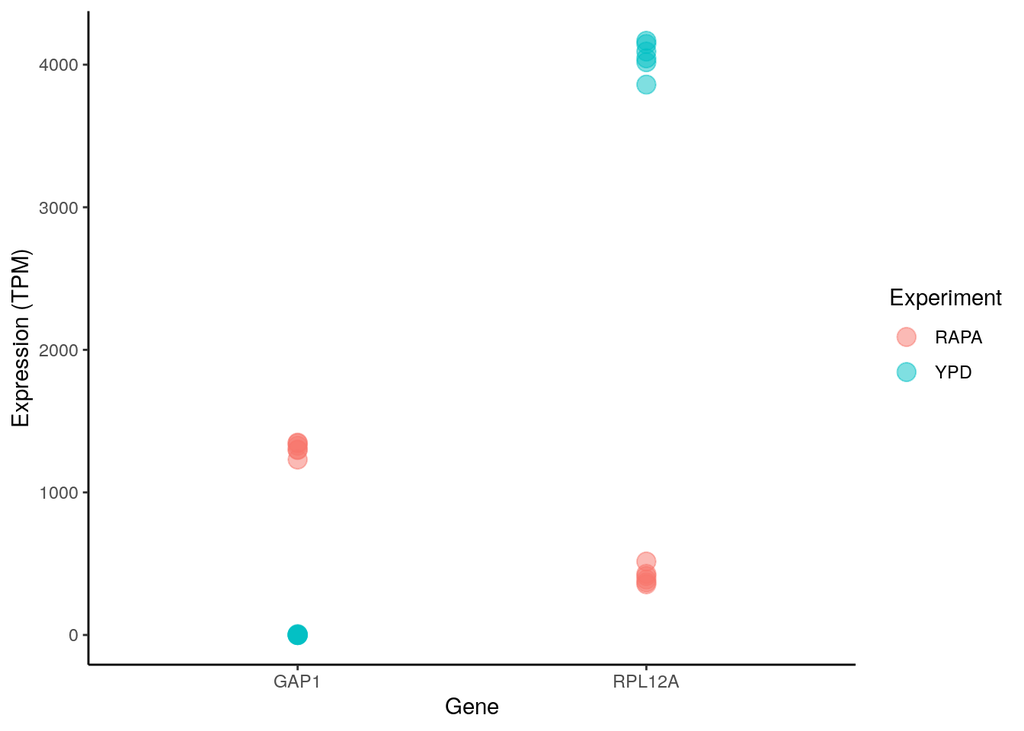

```r
rpl12a <- "YEL054C"
rpl12a.data <- plt.data.melt[plt.data.melt$Gene %in% c(rpl12a, gap1), ]

rpl12a.plt <- ggplot(rpl12a.data, aes(x=Gene, y=Expression, color=Experiment)) +
  geom_point(size=4, alpha=0.5) +
  scale_x_discrete(limits=c(gap1, rpl12a), labels=c("GAP1", "RPL12A")) +
  labs(y="Expression (TPM)")

print(rpl12a.plt)
```

This is a kinda weird plot though, and I miss my boxplots. Let’s try using `facet_grid()` instead.

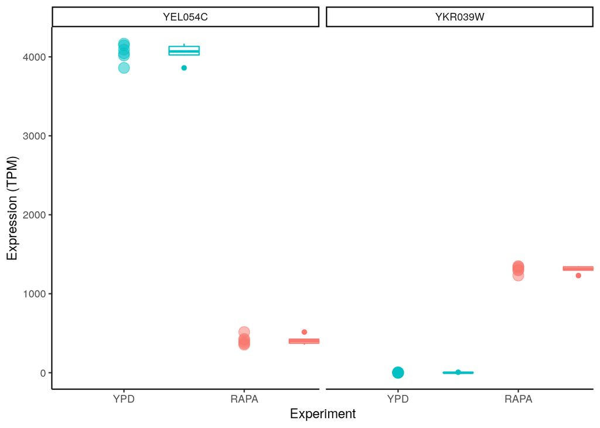

```r
faceted.plt <- ggplot(rpl12a.data, aes(x=Experiment, y=Expression, color=Experiment)) +
  geom_point(size=4, alpha=0.5) +
  geom_boxplot(position = position_nudge(x=0.5), width=0.25) +
  labs(y="Expression (TPM)") +
  scale_x_discrete(limits = c("YPD", "RAPA")) +
  facet_grid(~Gene) +
  theme(legend.position = "none")

print(faceted.plt)
```

## Geometries (What kind of plot)

Geometries define which kind of plot we want to draw. Some of them are more commonly used than others.

`geom_point` `geom_line` `geom_boxplot` `geom_histogram` `geom_tile`

Lets visualize all of this data in one giant heatmap using `geom_tile`.

First thing’s first; I want to convert each gene from TPM to log2(fold change) over the YPD mean.

```r
# First I want to only use genes with non-zero values
plt.data.foldchange <- plt.data.normalized[rowSums(plt.data.normalized == 0) == 0, c(ypd.replicates, rapa.replicates)]

# Then I want to normalize to the mean expression in YPD
plt.data.foldchange <- sweep(plt.data.foldchange, 1, rowMeans(plt.data.foldchange[, ypd.replicates]), FUN = "/")

# Now I want to take the log2
plt.data.foldchange <- log2(plt.data.foldchange)

# I'm going to cluster the data using hclust. We'll come back to clustering later in the course.
foldchange.hclust <- hclust(d=dist(plt.data.foldchange))

# And melt it for plotting
plt.data.foldchange <- melt.expression.data(plt.data.foldchange)
head(plt.data.foldchange)
```

```
##      Gene Replicate  Expression Experiment
## 1 YDL243C      YPD1  0.52309652        YPD
## 2 YDL237W      YPD1  0.27654236        YPD
## 3 YDL236W      YPD1 -0.05445571        YPD
## 4 YDL235C      YPD1 -0.28030323        YPD
## 5 YDL234C      YPD1 -0.75860650        YPD
## 6 YDL233W      YPD1 -1.48147245        YPD
```

Excellent - now I have the expression matrix in log2(fold change).

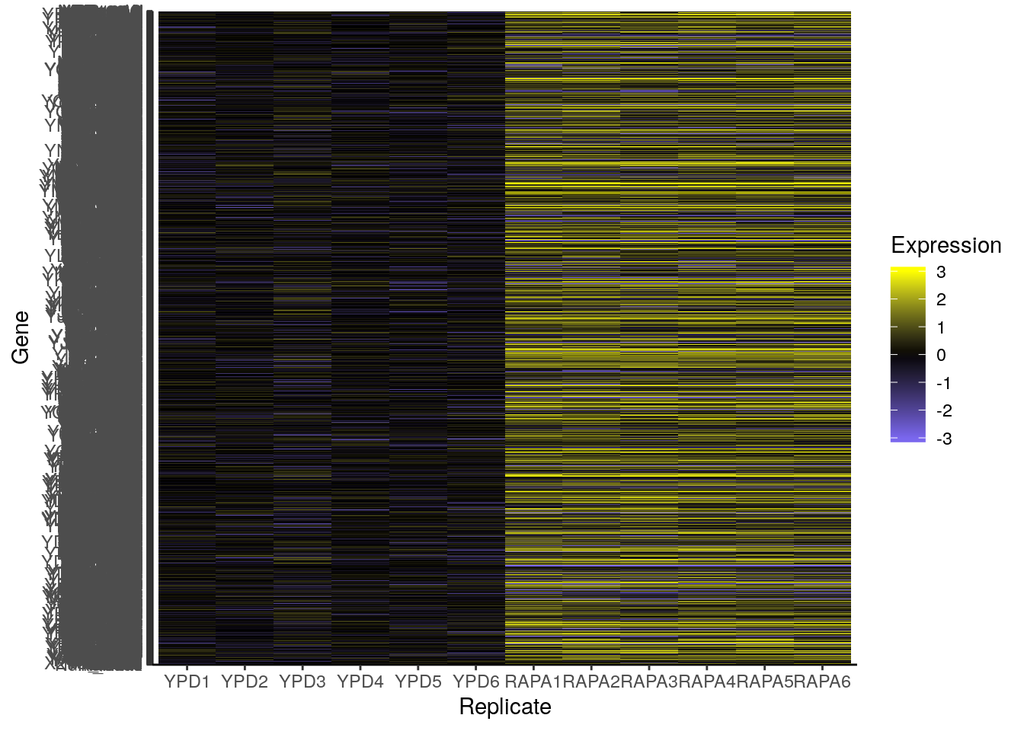

```r
# Create the plot
heatmap.plt <- ggplot(plt.data.foldchange, aes(x=Replicate, y=Gene, fill=Expression)) +
  geom_tile() +
  scale_fill_gradient2(low='slateblue2', mid='black', high='yellow', limits=c(-3, 3), oob=squish, na.value="white")

print(heatmap.plt)
```

## Theme

Well, that’s quite the mess. Let’s try to clean this up. Each element of the plot can be adjusted separately using the theme function.

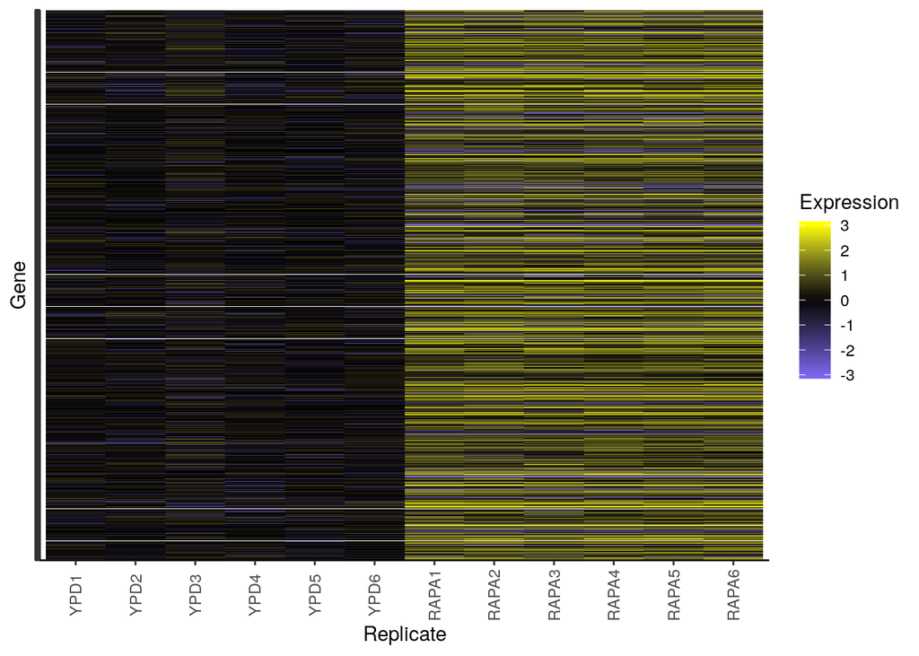

```r
# With element_text() we can change the text size, font, and positioning.
# With element_blank() we can make labels go away entirely
heatmap.plt <- heatmap.plt +
  theme(axis.text.y = element_blank(),
        axis.text.x = element_text(angle=90, hjust=0.5, vjust=0.5))
print(heatmap.plt)
```

Cleaner, but still hard to see any patterns. Let’s add that clustering order to the y-axis

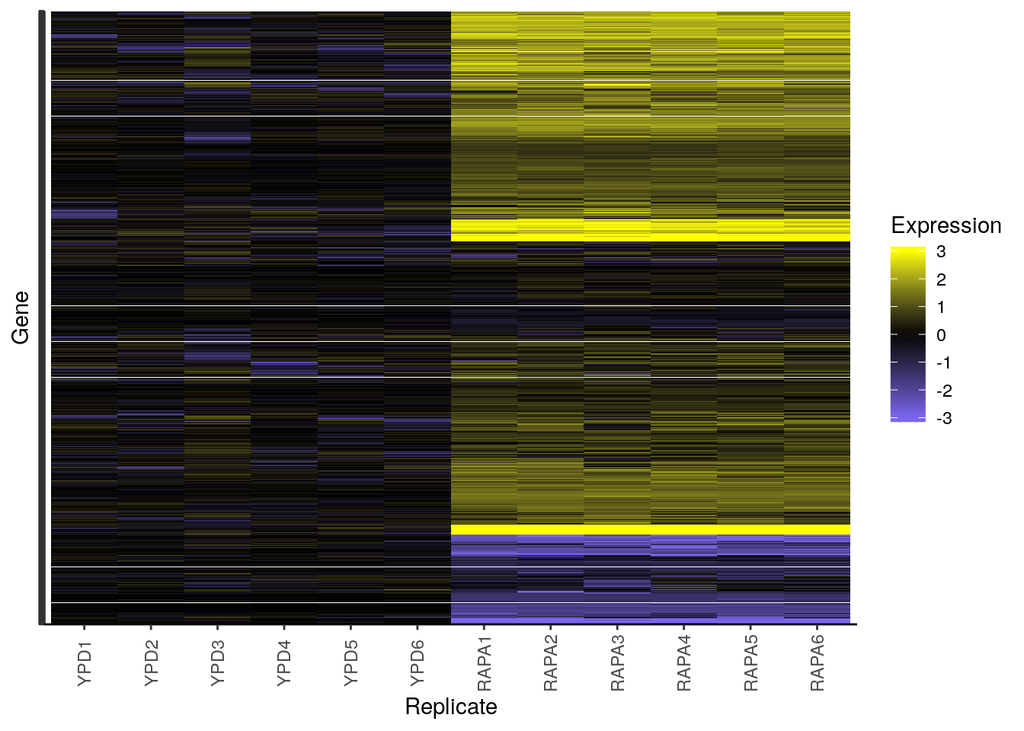

```r
# We'll come back to clustering methods later in the course
heatmap.plt <- heatmap.plt +
  scale_y_discrete(limits=foldchange.hclust$labels[foldchange.hclust$order])
print(heatmap.plt)
```

Now it’s starting to look lke a heatmap.

## Final layout

Lets use `cowplot` to lay out a full, multi-panel figure

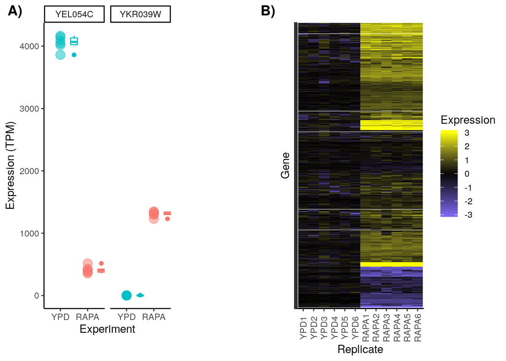

```r
require(cowplot)
final.figure <- cowplot::plot_grid(faceted.plt, heatmap.plt, ncol=2, labels = c("A)", "B)"), align = "hv", axis="tblr")
print(final.figure)
```

```r
# Now we can save the figure as a PDF and put it into the paper
ggsave("expression_and_heatmap.pdf", plot=final.figure, device=cairo_pdf, height=4, width=6, units='in', dpi=300)
```

## Lets explore some groups of genes

```r
group1 <- c("YHR174W", "YLR044C", "YGL253W", "YJR009C", "YGR192C")
group2 <- c("YPL265W", "YOR348C", "YNL142W", "YKR039W", "YMR088C")
group3 <- c("YEL054C", "YNL302C", "YLR061W", "YGL123W", "YOR063W")
group4 <- c("YGR282C", "YOR383C", "YLR390W.A", "YOL030W", "YLR110C")
group5 <- c("YDL014W", "YHR089C", "YHR072W.A", "YDL208W", "YLR197W")
```